# Taller 2 - Parte 1

Laura Katherine Martinez Castiblanco

# Lamado de base de datos y conexión con SQLite

Exploración de la base de datos

```r
# Listar todas las tablas de la base de datos
tablas <- dbListTables(con)
cat("Tablas disponibles:", paste(tablas, collapse=", "), "\n\n")
```

```
## Tablas disponibles: Album, Artist, Customer, Employee, Genre, Invoice, InvoiceLine, MediaType, Playlist, PlaylistTrack, Track
```

```r
# Inspeccionar las columnas de las tablas clave
cat("Columnas de la tabla 'Track':\n")
```

```
## Columnas de la tabla 'Track':
```

```r
print(dbListFields(con, "Track"))
```

```
## [1] "TrackId"      "Name"         "AlbumId"      "MediaTypeId"  "GenreId"
## [6] "Composer"     "Milliseconds" "Bytes"        "UnitPrice"
```

```r
cat("\nColumnas de la tabla 'Genre':\n")
```

```
##
## Columnas de la tabla 'Genre':
```

```r
print(dbListFields(con, "Genre"))
```

```
## [1] "GenreId" "Name"
```

```r
cat("\nColumnas de la tabla 'Album':\n")
```

```
##
## Columnas de la tabla 'Album':
```

```r
print(dbListFields(con, "Album"))
```

```
## [1] "AlbumId"  "Title"    "ArtistId"
```

Ejemplo de consulta

```sql
SELECT * FROM Track LIMIT 5;
```

Primeras 5 pistas

| TrackId | Name | AlbumId | MediaTypeId | GenreId | Composer | Milliseconds | Bytes | UnitPrice |
| --- | --- | --- | --- | --- | --- | --- | --- | --- |
| 1 | For Those About To Rock (We Salute You) | 1 | 1 | 1 | Angus Young, Malcolm Young, Brian Johnson | 343719 | 11170334 | 0.99 |
| 2 | Balls to the Wall | 2 | 2 | 1 | U. Dirkschneider, W. Hoffmann, H. Frank, P. Baltes, S. Kaufmann, G. Hoffmann | 342562 | 5510424 | 0.99 |
| 3 | Fast As a Shark | 3 | 2 | 1 | F. Baltes, S. Kaufman, U. Dirkscneider & W. Hoffman | 230619 | 3990994 | 0.99 |
| 4 | Restless and Wild | 3 | 2 | 1 | F. Baltes, R.A. Smith-Diesel, S. Kaufman, U. Dirkscneider & W. Hoffman | 252051 | 4331779 | 0.99 |
| 5 | Princess of the Dawn | 3 | 2 | 1 | Deaffy & R.A. Smith-Diesel | 375418 | 6290521 | 0.99 |

# Ejercicio 1: Análisis descriptivo de la colección musical

Con la base de datos Chinook, responde las siguientes preguntas usando sentencias SQL.

## 1. ¿Cuántas pistas hay en total en la base de datos?

Usando la función de agregación `COUNT()`.

```sql
SELECT COUNT(TrackId) AS total_pistas
FROM Track;
```

1 records

| total_pistas |
| --- |
| 3503 |

## 2. ¿Cuántos géneros distintos existen?

Contar los géneros directamente desde la tabla `Genre`.

```sql
SELECT COUNT(GenreId) AS total_generos
FROM Genre;
```

1 records

| total_generos |
| --- |
| 25 |

## 3. Obtén el nombre del género, el número de pistas y la duración promedio (en minutos) para cada género.

Ordena de mayor a menor número de pistas.

Se relaciona la tabla `Track` con `Genre` mediante un `INNER JOIN`. Agrupando por el nombre del género y ordenando de forma descendente (`DESC`).

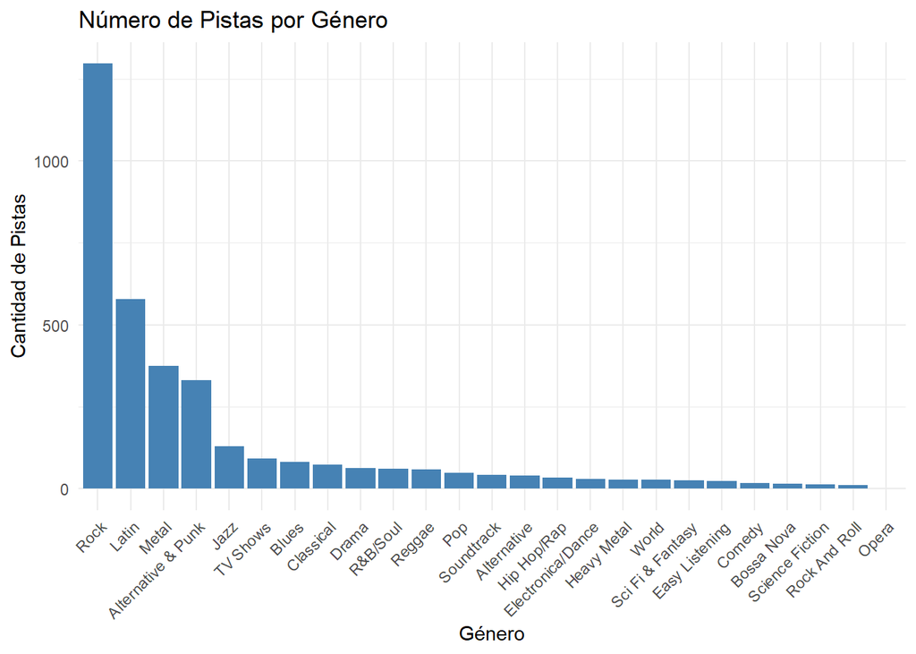

```sql
SELECT
    g.Name AS genero,
    COUNT(t.TrackId) AS num_pistas,
    ROUND(AVG(t.Milliseconds) / 60000.0, 2) AS duracion_prom_min
FROM Track t
JOIN Genre g ON t.GenreId = g.GenreId
GROUP BY g.Name
ORDER BY num_pistas DESC;
```

## 4. ¿Cuáles son las 5 pistas más largas? Muestra el nombre, el álbum y la duración en minutos.

Se une la tabla `Track` con `Album` para obtener el nombre del álbum. Posteriormente se ordena por la duración en milisegundos de forma descendente y se limita a 5.

```sql
SELECT
    t.Name AS pista,
    al.Title AS album,
    ROUND(t.Milliseconds / 60000.0, 2) AS duracion_min
FROM Track t
JOIN Album al ON t.AlbumId = al.AlbumId
ORDER BY t.Milliseconds DESC
LIMIT 5;
```

5 records

| pista | album | duracion_min |
| --- | --- | --- |
| Occupation / Precipice | Battlestar Galactica, Season 3 | 88.12 |
| Through a Looking Glass | Lost, Season 3 | 84.81 |
| Greetings from Earth, Pt. 1 | Battlestar Galactica (Classic), Season 1 | 49.34 |
| The Man With Nine Lives | Battlestar Galactica (Classic), Season 1 | 49.28 |
| Battlestar Galactica, Pt. 2 | Battlestar Galactica (Classic), Season 1 | 49.27 |

## 5. ¿Cuántas pistas tienen un `UnitPrice` superior a $0.99? ¿Qué porcentaje representan del total?

Se cuenta el número de pista que cumplen la condición y se divide por el total de pistas en la tabla, por 100 para el porcentaje.

```sql
SELECT
    COUNT(CASE WHEN UnitPrice > 0.99 THEN 1 END) AS pistas_mayores_099,
    COUNT(*) AS total_pistas,
    ROUND(COUNT(CASE WHEN UnitPrice > 0.99 THEN 1 END) * 100.0 / COUNT(*), 2) AS porcentaje
FROM Track;
```

1 records

| pistas_mayores_099 | total_pistas | porcentaje |
| --- | --- | --- |
| 213 | 3503 | 6.08 |

## 6. Calcula la media, mínimo, máximo y varianza (en SQL) de la duración en milisegundos de todas las pistas.

Dado que SQLite no posee una función nativa para la varianza, se emplea la identidad algebraica `AVG(x^2) - (AVG(x))^2`.

```sql
SELECT
    ROUND(AVG(Milliseconds), 2) AS media_ms,
    MIN(Milliseconds) AS minimo_ms,
    MAX(Milliseconds) AS maximo_ms,
    ROUND(AVG(Milliseconds * Milliseconds) - (AVG(Milliseconds) * AVG(Milliseconds)), 2) AS varianza_ms
FROM Track;
```

1 records

| media_ms | minimo_ms | maximo_ms | varianza_ms |
| --- | --- | --- | --- |
| 393599.2 | 1071 | 5286953 | 286149105505 |

# Ejercicio 2: Análisis descriptivo de ventas

Usando las tablas `Invoice` (facturas) e `InvoiceLine` (líneas de factura), responde:

## 1. ¿Cuál es el total de ingresos generados por la tienda? ¿Y el promedio por factura?

Se emplea las funciones de agregación `SUM()` y `AVG()` sobre la columna `Total` de la tabla `Invoice`.

```sql
SELECT
    SUM(Total) AS total_ingresos,
    ROUND(AVG(Total), 2) AS promedio_por_factura
FROM Invoice;
```

1 records

| total_ingresos | promedio_por_factura |
| --- | --- |
| 2328.6 | 5.65 |

## 2. ¿Cuántas facturas se emitieron por año? Ordena cronológicamente.

Para extraer el año de la columna `InvoiceDate`, se usa la función `SUBSTR()` que extrae una subcadena de texto. Luego se agrupa por año y contamos las facturas. Finalmente se ordena de forma ascendente.

```sql
SELECT
    SUBSTR(InvoiceDate, 1, 4) AS anho,
    COUNT(InvoiceId) AS num_facturas
FROM Invoice
GROUP BY anho
ORDER BY anho ASC;
```

5 records

| anho | num_facturas |
| --- | --- |
| 2021 | 83 |
| 2022 | 83 |
| 2023 | 83 |
| 2024 | 83 |
| 2025 | 80 |

## 3. Identifica los **5 países con más ingresos**. Muestra: país, número de facturas, ingreso total y promedio por factura.

Se agrupa por `BillingCountry` y calcula el número de facturas, el ingreso total y el promedio por facturas. Se ordena de forma descendente y se limita a los primeros 5.

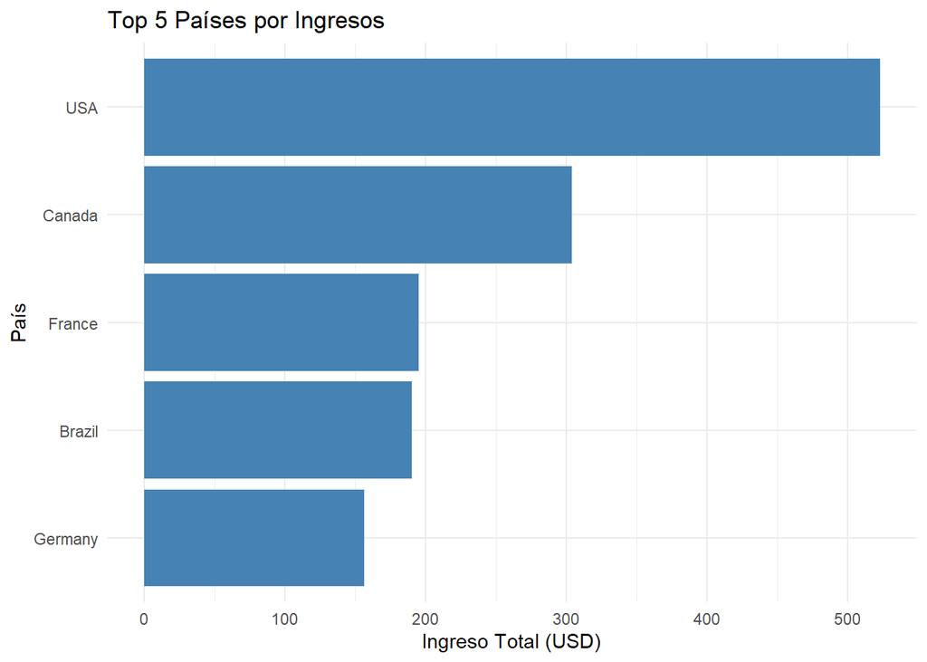

```sql
SELECT
    BillingCountry AS pais,
    COUNT(InvoiceId) AS num_facturas,
    ROUND(SUM(Total), 2) AS ingreso_total,
    ROUND(AVG(Total), 2) AS promedio_por_factura
FROM Invoice
GROUP BY pais
ORDER BY ingreso_total DESC
LIMIT 5;
```

## 4. ¿Cuál es la desviación estándar del total de facturas? Calcula primero la varianza en SQL y luego obtén la raíz en R o Python.

La varianza poblacional se calcula como:

**Var(X) = AVG(X²) - (AVG(X))²**.

```sql
SELECT
    AVG(Total * Total) - (AVG(Total) * AVG(Total)) AS varianza_total
FROM Invoice;
```

Se tiene la varianza guardada en la variable `resultado_varianza`, la cual se emplea en R para calcular la raíz cuadrada y obtener la desviación estándar.

```r
# Extraemos el valor de la varianza del data frame resultado
valor_varianza <- resultado_varianza$varianza_total[1]

# Calculamos la raíz cuadrada para obtener la desviación estándar
desviacion_estandar <- sqrt(valor_varianza)

cat("La varianza del total de facturas es:", valor_varianza, "\n")
```

```
## La varianza del total de facturas es: 22.4634
```

```r
cat("La desviación estándar del total de facturas es:", desviacion_estandar, "\n")
```

```
## La desviación estándar del total de facturas es: 4.739557
```

## 5. Encuentra los meses con mayor y menor ingreso promedio.

Con `SUBSTR(InvoiceDate, 6, 2)` se extrae los caracteres en la posición 6 y 7 (correspondientes al mes en formato YYYY-MM-DD). Se agrupa por mes y calcula el promedio de ingreso.

```sql
SELECT
    SUBSTR(InvoiceDate, 6, 2) AS mes,
    COUNT(InvoiceId) AS num_facturas,
    ROUND(AVG(Total), 2) AS ingreso_promedio
FROM Invoice
GROUP BY mes
ORDER BY ingreso_promedio DESC;
```

Visualizamos los resultados:

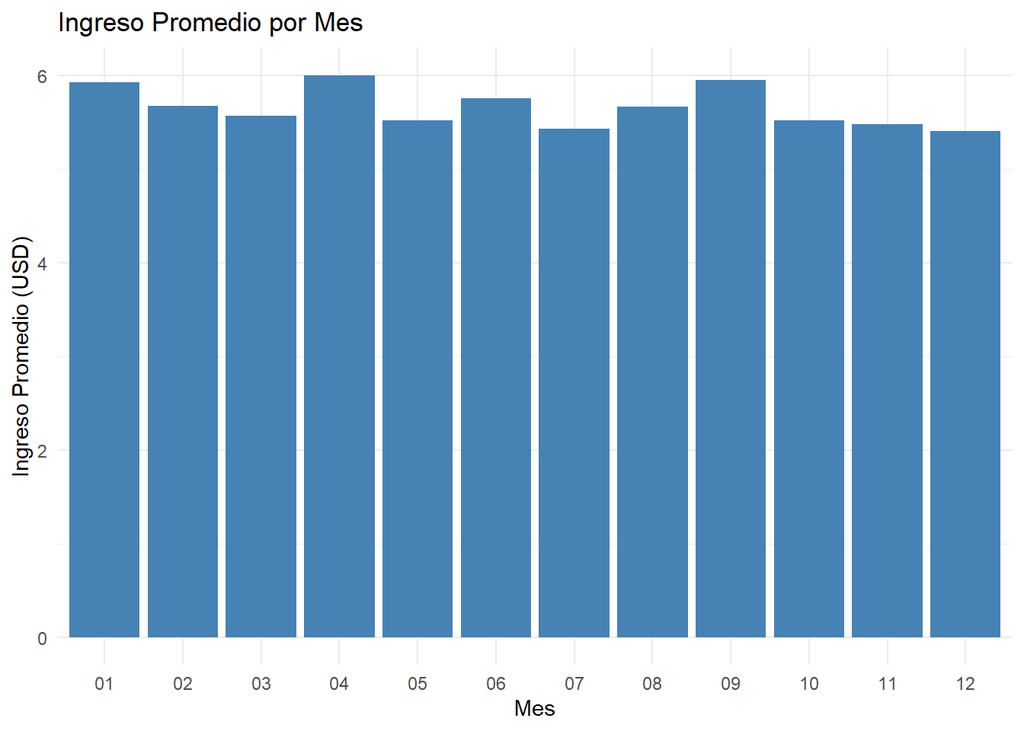